# eksamen_2022v_285

# 1. Prosess

## a)

### i.

**Tegn sannsynlighetsfordelingene (pdf) for** $X \thicksim bin_{(8, p)}(x)$ **for p = 0.25,p = 0.5,p = 0.75, i hvert sitt diagram.**

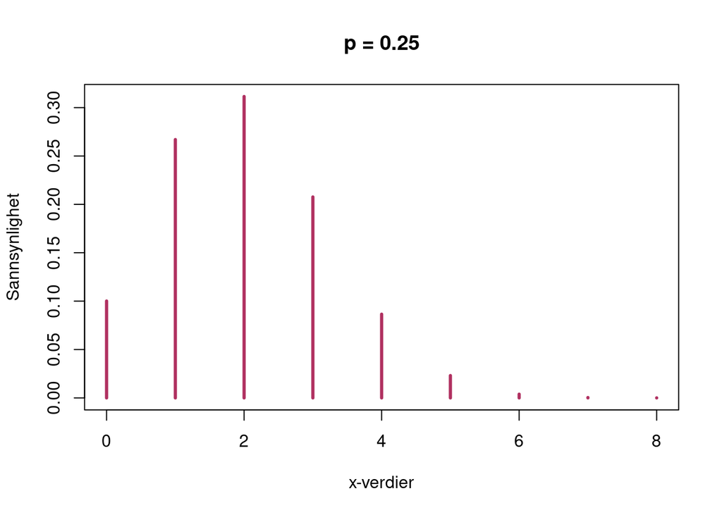

```r
# Setter opp variabler for de forskjellige verdiene for p
p_1_a = 0.25
p_2_a = 0.5
p_3_a = 0.75

# Lager x-verdier som går fra 0 til 8, siden n = 8, og har step på 1 siden den skal være diskret
xVerdier = seq(0, 8, 1)

plot(xVerdier, dbinom(xVerdier, 8, p_1_a), ylab="Sannsynlighet", xlab="x-verdier", type="h", col="maroon", lwd=3, main="p = 0.25")
```

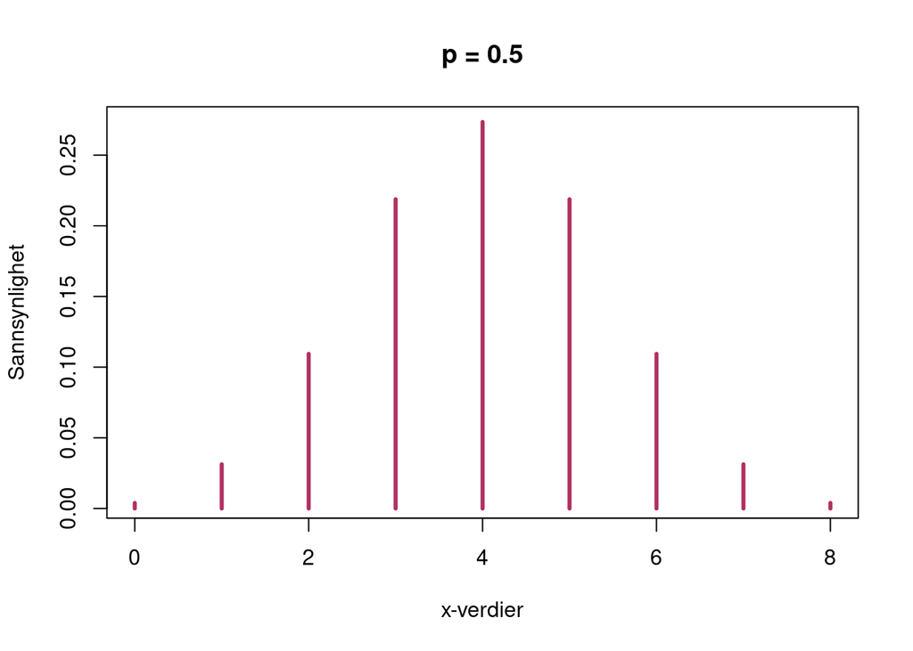

```r
plot(xVerdier, dbinom(xVerdier, 8, p_2_a), ylab="Sannsynlighet", xlab="x-verdier", type="h", col="maroon", lwd=3, main="p = 0.5")
```

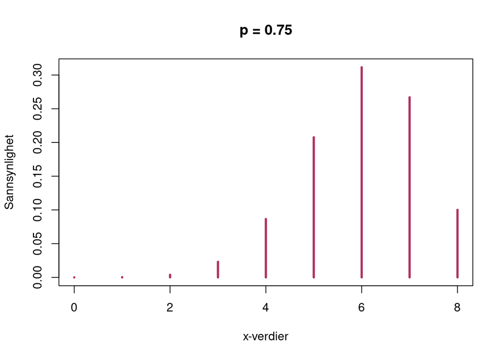

```r
plot(xVerdier, dbinom(xVerdier, 8, p_3_a), ylab="Sannsynlighet", xlab="x-verdier", type="h", col="maroon", lwd=3, main="p = 0.75")
```

### ii. **Hva slags effekt har en høyere verdi for p på grafen, sammenlignet med en lavere verdi?**

Da vil frekvensen ha en trend mot høyre på grafen, altså at det er flere forekomster av de høyere verdiene hvis p er stor.

### iii.

**Du skal slå en mynt 8 gonger. Du vinner dersom det blir presis 4 eller presis 5 mynt, men taper elles. Du kan velge mellom tre forskjellige mynter, med pn = P(mynt) respektivt p1 = 0.25, p2 = 0.5, og p3 = 0.75. Hvilken av de tre myntene gir deg størst sannsynlighet for å vinne?**

Siden p’en vil gjøre at trenden går mot den prosenten i grafen (altså når n = 8 så vil 0.5 ha en trend på rundt 4) gir det mening å velge p2 = 0.5 siden den mynten vil ha størt sannsynlighet for å få en verdi rundt 4. Det kan vi se på den forrige oppgaven der en p = 0.5 vil ha størst sannsynlighet å ha 4 suksesser, i dette tilfelle vil én suksess være å få mynt.

## b)

**Du kjører på skogsveiene i Åmli, og gjennomsnittlig antall hull i veienper kilometer er lik kandidatnummeret ditt på denne eksamenen.**

Mitt kandidat nummber er 285, så da vil $\lambda = 285$.

### i.

**Hva slags prosess må du bruke for å drive statistikk om vei `hullene i Åmlis skogsveier, og hva er verdien på parameteren(e) for prosessen?**

Her vil jeg velge å bruke en poisson-prosess ettersom vi forventer $\lambda$ antall hull på den gitte avstanden, altså 285 hull per 1000 meter.

### ii.

**Hva er sannsynlighetsfordelingen for antall hull de neste 100 meterne?** For å da finne sannsynlighetsfordelingen bruker jeg formelen for kjent $\lambda$ etter $\theta$ antall sukksesser. Enheten som er i denne oppgaven er per 1000 meter, derfor blir $\theta$ her da $\frac{100m}{1000m} = 0.1$.

$$N_{+\theta} \thicksim
pois_{\lambda\theta}(x)$$

$$N_{+\theta} \thicksim pois_{(285
\hspace{1mm} \cdot \hspace{1mm} 0.1)}(x)$$
### iii. **Hva er sannsynligheten for at du finner mer enn 30 hull de neste 100 meterne?**

Bruker fordelingen fra forrige steg for å finne hva sannsynligheten er for $x = 30$.

```r
lambda = 285
unit = 0.1 # km

sanns_30_hull = 1 - ppois(30, 285 * 0.1)
```

Da får jeg at det er en $0.3440776 \approx 0.3441 = 34.41\%$ sannsynlighet for å finne mer enn 30 hull.

## c)

### i.

**Hvilken ”pdf” og hvilken ”CDF” tilhører ikke en sannsynlighetsfordeling?**

### ii.

**Hvilken pdf hører sammen med hvilken CDF?**

- c hører med A

### iii.

**Hvilke sannsynlighetsfordelinger er diskrete?**

### iv.

**Hvilke sannsynlighetsfordelinger kan være sannsynlighetsfordelinger for andeler og sannsynligheter? Hvorfor?**

# 2. Inferens

## a)

**Tabellversjonen av Bayes teorem: Du hører på statistikk-podcasten til to grupper. La oss kalle dem gruppe Kul og gruppe Flink**

### i.

**Prior: La prior sannsynlighet være proporsjonal med antall podcasts hvergruppe har laget. Kul har laget 7 podcasts, Flink har laget 4. Hva er de respektive prior sannsynlighetene?**

```r
# Prior

# Antall kul = 7
# Antall flink = 4
# totalt = 11
ant_kul = 7
ant_flink = 4
tot_podcast = 11

# _k = kul --- _f = flink
A_k = ant_kul / tot_podcast
A_k
```

```
## [1] 0.6363636
```

```r
A_f = ant_flink / tot_podcast
A_f
```

```
## [1] 0.3636364
```

### ii.

**begge de to gruppene trekker de lodd om hvem i gruppa som skal innledesendingen. Kul har 4 gutter og 2 jenter, mens Flink har 2 gutter og 4 jenter. Den sendingen du hører på blir innledet av en jente. Oppdatér sannsynlighetene for hvilken av gruppene du lytter til nå**

```r
# Likelihood

# Setter opp A som innledet av gutt, og B som innledet av jente
tot_gruppemedlemmer = 2 + 4
B_gitt_kul = 2 / tot_gruppemedlemmer
B_gitt_kul
```

```
## [1] 0.3333333
```

```r
B_gitt_flink = 4 / tot_gruppemedlemmer
B_gitt_flink
```

```
## [1] 0.6666667
```

```r
# Joint probability

samsannsynlighet_kul = A_k * B_gitt_kul
samsannsynlighet_kul
```

```
## [1] 0.2121212
```

```r
samsannsynlighet_flink = A_f * B_gitt_flink
samsannsynlighet_flink
```

```
## [1] 0.2424242
```

```r
# Total probability

tot_samsannsynlighet = samsannsynlighet_kul + samsannsynlighet_flink
tot_samsannsynlighet
```

```
## [1] 0.4545455
```

```r
# Posterior

post_kul = samsannsynlighet_kul / tot_samsannsynlighet
post_kul
```

```
## [1] 0.4666667
```

```r
post_flink = samsannsynlighet_flink / tot_samsannsynlighet
post_flink
```

```
## [1] 0.5333333
```

### iii.

**Gruppe Kul skåler for statistikken innen 5 minutt etter introen på 70% av podcastene sine. Gruppe Flink skåler ikke på sine podcasts. Hva er sannsynligheten for at de kommer til å skåle innen 5 minutter på podcasten du nå hører på?**

```r
# Går igjennom tabellen enda en gang, men nå bruker jeg posterior fra forrige gang som prior

# Likelihood
B_gitt_kul_2 = 0.7 # fordi de skåler 70% av tiden
B_gitt_flink_2 = 0 # fordi de aldri skåler

# Joint probability

samsannsynlighet_kul_2 = B_gitt_kul_2 * post_kul
samsannsynlighet_flink_2 = B_gitt_flink_2 * post_flink

totalsannsynlighet_skaal = samsannsynlighet_kul_2 + samsannsynlighet_flink_2
```

Da blir den totale sannsynligheten for at vi hører på en podcast det skåles innen 5 minutter $0.3266667 \approx 32.67\%$.

## b)

Mitt kandidat nr er 285, derfor blir Jedi = 41 og Sith = 22.

### i.

**Bruk Jeffreys’ prior hyperparametre for** $\pi$**. Du finner observasjonene i tabellen under. Finn posterior sannsynlighetsfordeling for**$\pi$**, og tegn både pdf (og cdf) for sannsynlighetsfordelingen.**

```r
# Sette inn Jeffreys prior som a_0 og b_0
a_0_bern = 0.5
b_0_bern = 0.5

k_bern = 41
l_bern = 22

a_1_bern = a_0_bern + k_bern
b_1_bern = b_0_bern + l_bern
a_1_bern
```

```
## [1] 41.5
```

```r
b_1_bern
```

```
## [1] 22.5
```

Sannsynlighetsfordelingen for $\pi$: $\beta_{(41.5, 22.5)}(t)$

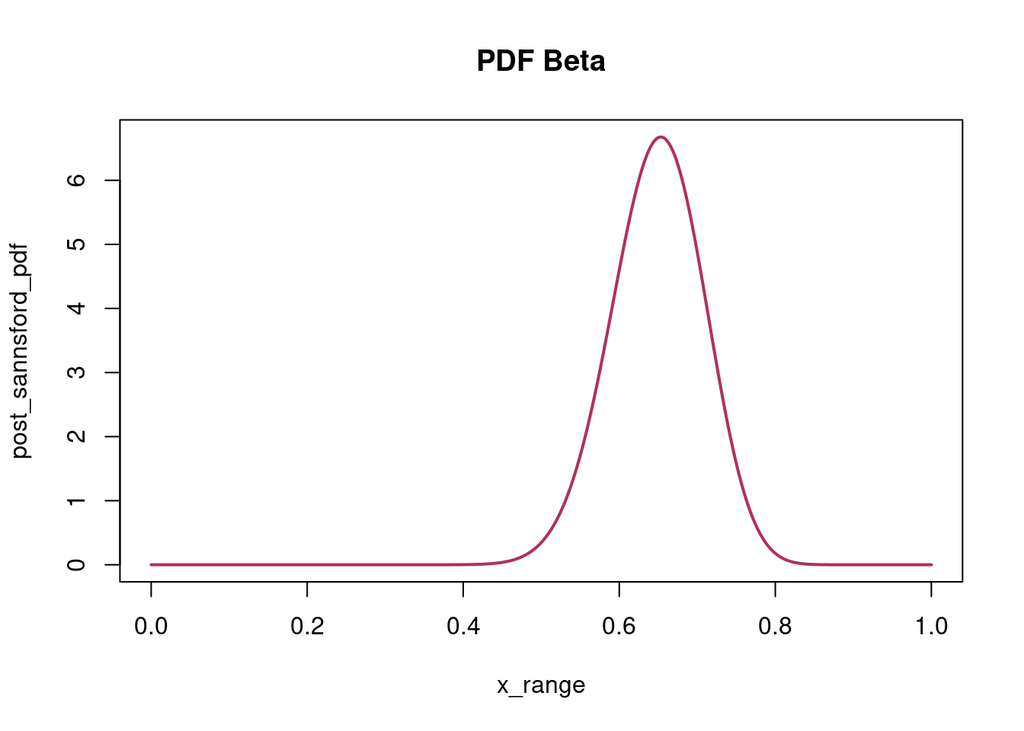

```r
x_range = seq(0, 1, 0.001)

post_sannsford_pdf = dbeta(x_range, a_1_bern, b_1_bern)

plot(x_range, post_sannsford_pdf, type="l", col="maroon", lwd=2, main="PDF Beta")
```

### ii.

**Regn ut et 70% intervallestimat (”kredibilitetsintervall”) for** $\pi$**, tegn CDF for sannsynlighetsfordelingen for** $\pi$ **og markér intervallestimatet på dennekurven.**

```r
nedre_prosent = (1 - 0.7)/2
ovre_prosent = 1 - nedre_prosent

end_interval = qbeta(ovre_prosent, a_1_bern, b_1_bern)
end_interval
```

```
## [1] 0.7100813
```

```r
begin_interval = qbeta(nedre_prosent, a_1_bern, b_1_bern)
begin_interval
```

```
## [1] 0.5865321
```

[figure not shown]

### iii.

**Tegn en konfidenskurve for** $\pi$ **, og markér 70% intervallestimatet for** $\pi$ **på denne kurven.**

```r
a_1_bern
```

```
## [1] 41.5
```

```r
b_1_bern
```

```
## [1] 22.5
```

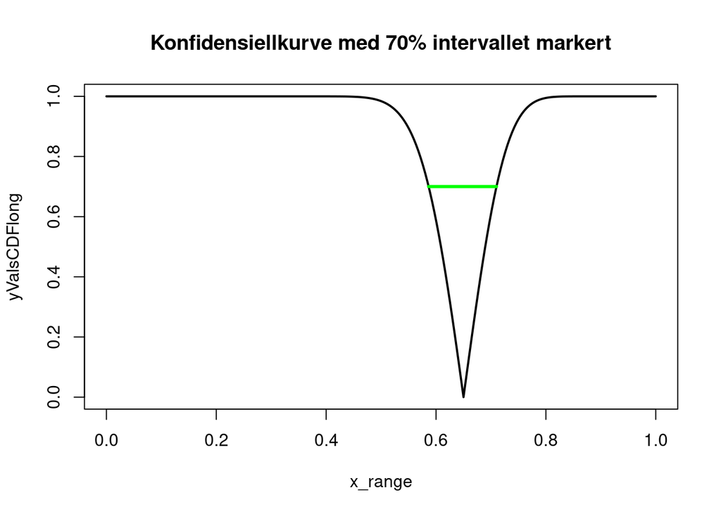

```r
yValsCDFlong=abs(2*pbeta(x_range, a_1_bern, b_1_bern) - 1)

plot(x_range, yValsCDFlong, type="l", lwd=2, main="Konfidensiellkurve med 70% intervallet markert")
segments(begin_interval, 0.7, end_interval, 0.7, col="green", lwd=3)
```

## c)

### i.

### ii.

### iii.